# graphs, line chart, scatter plot, bar cahrt, histogram,

# pie chart, stack plot, polar plot, boxplot, violin plot,

# matrix plot, heatmap, acorr, angles sprectum, axes,axis,

# contour, draw, loglog, margins, text, title, triplot,

# limiting area, range, style, customization

# -------------------------------------------------------------------------------------------------------------

```python
import pandas as pd
import numpy as np
import matplotlib.pyplot as plt
import seaborn as sns
```

```python
data1 = pd.read_csv('F:\excel\Sales.csv')
data2 = pd.read_excel('F:\excel\Orders list.xlsx')
data3 = pd.read_csv(r'F:\excel\city_temperature.csv')
```

```python
data5 = data1[1000:1500]
data6 = data3[0:1000]
data4 = data3[(data3['City'] == 'Algiers') & (data3['Month'] == 1) & (data3['Year'] == 1995) ]
```

```python
data1
```

|  | Date | Day | Month | Year | Customer_Age | Age_Group | Customer_Gender | Country | State | Product_Category | Sub_Category | Product | Order_Quantity | Unit_Cost | Unit_Price | Profit | Cost | Revenue |
| --- | --- | --- | --- | --- | --- | --- | --- | --- | --- | --- | --- | --- | --- | --- | --- | --- | --- | --- |
| 0 | 2013-11-26 | 26 | November | 2013 | 19 | Youth (<25) | M | Canada | British Columbia | Accessories | Bike Racks | Hitch Rack - 4-Bike | 8 | 45 | 120 | 590 | 360 | 950 |
| 1 | 2015-11-26 | 26 | November | 2015 | 19 | Youth (<25) | M | Canada | British Columbia | Accessories | Bike Racks | Hitch Rack - 4-Bike | 8 | 45 | 120 | 590 | 360 | 950 |
| 2 | 2014-03-23 | 23 | March | 2014 | 49 | Adults (35-64) | M | Australia | New South Wales | Accessories | Bike Racks | Hitch Rack - 4-Bike | 23 | 45 | 120 | 1366 | 1035 | 2401 |
| 3 | 2016-03-23 | 23 | March | 2016 | 49 | Adults (35-64) | M | Australia | New South Wales | Accessories | Bike Racks | Hitch Rack - 4-Bike | 20 | 45 | 120 | 1188 | 900 | 2088 |
| 4 | 2014-05-15 | 15 | May | 2014 | 47 | Adults (35-64) | F | Australia | New South Wales | Accessories | Bike Racks | Hitch Rack - 4-Bike | 4 | 45 | 120 | 238 | 180 | 418 |
| ... | ... | ... | ... | ... | ... | ... | ... | ... | ... | ... | ... | ... | ... | ... | ... | ... | ... | ... |
| 113031 | 2016-04-12 | 12 | April | 2016 | 41 | Adults (35-64) | M | United Kingdom | England | Clothing | Vests | Classic Vest, S | 3 | 24 | 64 | 112 | 72 | 184 |
| 113032 | 2014-04-02 | 2 | April | 2014 | 18 | Youth (<25) | M | Australia | Queensland | Clothing | Vests | Classic Vest, M | 22 | 24 | 64 | 655 | 528 | 1183 |
| 113033 | 2016-04-02 | 2 | April | 2016 | 18 | Youth (<25) | M | Australia | Queensland | Clothing | Vests | Classic Vest, M | 22 | 24 | 64 | 655 | 528 | 1183 |
| 113034 | 2014-03-04 | 4 | March | 2014 | 37 | Adults (35-64) | F | France | Seine (Paris) | Clothing | Vests | Classic Vest, L | 24 | 24 | 64 | 684 | 576 | 1260 |
| 113035 | 2016-03-04 | 4 | March | 2016 | 37 | Adults (35-64) | F | France | Seine (Paris) | Clothing | Vests | Classic Vest, L | 23 | 24 | 64 | 655 | 552 | 1207 |

113036 rows × 18 columns

```python
data2
```

|  | Order | Order Date | Order Quantity | Sales | Ship Mode | Profit | Unit Price | Customer Name | Customer Segment | Product Category |
| --- | --- | --- | --- | --- | --- | --- | --- | --- | --- | --- |
| 0 | 3 | 2010-10-13 | 6 | 261.5400 | Regular Air | -213.250 | 38.94 | Muhammed MacIntyre | Small Business | Office Supplies |
| 1 | 6 | 2012-02-20 | 2 | 6.9300 | Regular Air | -4.640 | 2.08 | Ruben Dartt | Corporate | Office Supplies |
| 2 | 32 | 2011-07-15 | 26 | 2808.0800 | Regular Air | 1054.820 | 107.53 | Liz Pelletier | Corporate | Furniture |
| 3 | 32 | 2011-07-15 | 24 | 1761.4000 | Delivery Truck | -1748.560 | 70.89 | Liz Pelletier | Corporate | Furniture |
| 4 | 32 | 2011-07-15 | 23 | 160.2335 | Regular Air | -85.129 | 7.99 | Liz Pelletier | Corporate | Technology |
| ... | ... | ... | ... | ... | ... | ... | ... | ... | ... | ... |
| 1002 | 7171 | 2011-02-13 | 17 | 303.1865 | Regular Air | 92.592 | 20.99 | Andy Gerbode | Consumer | Technology |
| 1003 | 7174 | 2012-03-10 | 10 | 141.9200 | Regular Air | 12.200 | 13.73 | Thomas Thornton | Consumer | Furniture |
| 1004 | 7175 | 2010-02-07 | 10 | 748.2500 | Delivery Truck | -86.990 | 70.98 | Helen Andreada | Corporate | Furniture |
| 1005 | 7203 | 2009-01-08 | 25 | 21752.0100 | Regular Air | 9296.348 | 896.99 | Ruben Dartt | Corporate | Office Supplies |
| 1006 | 7239 | 2011-06-29 | 50 | 6206.1600 | Regular Air | 1416.270 | 120.33 | Craig Carroll | Small Business | Office Supplies |

1007 rows × 10 columns

```python
data3
```

|  | Region | Country | State | City | Month | Day | Year | AvgTemperature |
| --- | --- | --- | --- | --- | --- | --- | --- | --- |
| 0 | Africa | Algeria | NaN | Algiers | 1 | 1 | 1995 | 64.2 |
| 1 | Africa | Algeria | NaN | Algiers | 1 | 2 | 1995 | 49.4 |
| 2 | Africa | Algeria | NaN | Algiers | 1 | 3 | 1995 | 48.8 |
| 3 | Africa | Algeria | NaN | Algiers | 1 | 4 | 1995 | 46.4 |
| 4 | Africa | Algeria | NaN | Algiers | 1 | 5 | 1995 | 47.9 |
| ... | ... | ... | ... | ... | ... | ... | ... | ... |
| 2906322 | North America | US | Additional Territories | San Juan Puerto Rico | 7 | 27 | 2013 | 82.4 |
| 2906323 | North America | US | Additional Territories | San Juan Puerto Rico | 7 | 28 | 2013 | 81.6 |
| 2906324 | North America | US | Additional Territories | San Juan Puerto Rico | 7 | 29 | 2013 | 84.2 |
| 2906325 | North America | US | Additional Territories | San Juan Puerto Rico | 7 | 30 | 2013 | 83.8 |
| 2906326 | North America | US | Additional Territories | San Juan Puerto Rico | 7 | 31 | 2013 | 83.6 |

2906327 rows × 8 columns

```python
data4
```

|  | Region | Country | State | City | Month | Day | Year | AvgTemperature |
| --- | --- | --- | --- | --- | --- | --- | --- | --- |
| 0 | Africa | Algeria | NaN | Algiers | 1 | 1 | 1995 | 64.2 |
| 1 | Africa | Algeria | NaN | Algiers | 1 | 2 | 1995 | 49.4 |
| 2 | Africa | Algeria | NaN | Algiers | 1 | 3 | 1995 | 48.8 |
| 3 | Africa | Algeria | NaN | Algiers | 1 | 4 | 1995 | 46.4 |
| 4 | Africa | Algeria | NaN | Algiers | 1 | 5 | 1995 | 47.9 |
| 5 | Africa | Algeria | NaN | Algiers | 1 | 6 | 1995 | 48.7 |
| 6 | Africa | Algeria | NaN | Algiers | 1 | 7 | 1995 | 48.9 |
| 7 | Africa | Algeria | NaN | Algiers | 1 | 8 | 1995 | 49.1 |
| 8 | Africa | Algeria | NaN | Algiers | 1 | 9 | 1995 | 49.0 |
| 9 | Africa | Algeria | NaN | Algiers | 1 | 10 | 1995 | 51.9 |
| 10 | Africa | Algeria | NaN | Algiers | 1 | 11 | 1995 | 51.7 |
| 11 | Africa | Algeria | NaN | Algiers | 1 | 12 | 1995 | 51.3 |
| 12 | Africa | Algeria | NaN | Algiers | 1 | 13 | 1995 | 47.0 |
| 13 | Africa | Algeria | NaN | Algiers | 1 | 14 | 1995 | 46.9 |
| 14 | Africa | Algeria | NaN | Algiers | 1 | 15 | 1995 | 47.5 |
| 15 | Africa | Algeria | NaN | Algiers | 1 | 16 | 1995 | 45.9 |
| 16 | Africa | Algeria | NaN | Algiers | 1 | 17 | 1995 | 44.5 |
| 17 | Africa | Algeria | NaN | Algiers | 1 | 18 | 1995 | 50.7 |
| 18 | Africa | Algeria | NaN | Algiers | 1 | 19 | 1995 | 54.0 |
| 19 | Africa | Algeria | NaN | Algiers | 1 | 20 | 1995 | 52.6 |
| 20 | Africa | Algeria | NaN | Algiers | 1 | 21 | 1995 | 54.2 |
| 21 | Africa | Algeria | NaN | Algiers | 1 | 22 | 1995 | 51.0 |
| 22 | Africa | Algeria | NaN | Algiers | 1 | 23 | 1995 | 53.5 |
| 23 | Africa | Algeria | NaN | Algiers | 1 | 24 | 1995 | 54.2 |
| 24 | Africa | Algeria | NaN | Algiers | 1 | 25 | 1995 | 54.2 |
| 25 | Africa | Algeria | NaN | Algiers | 1 | 26 | 1995 | 52.6 |
| 26 | Africa | Algeria | NaN | Algiers | 1 | 27 | 1995 | 55.5 |
| 27 | Africa | Algeria | NaN | Algiers | 1 | 28 | 1995 | 53.8 |
| 28 | Africa | Algeria | NaN | Algiers | 1 | 29 | 1995 | 54.3 |
| 29 | Africa | Algeria | NaN | Algiers | 1 | 30 | 1995 | 57.4 |
| 30 | Africa | Algeria | NaN | Algiers | 1 | 31 | 1995 | 56.9 |

```python
data5
```

|  | Date | Day | Month | Year | Customer_Age | Age_Group | Customer_Gender | Country | State | Product_Category | Sub_Category | Product | Order_Quantity | Unit_Cost | Unit_Price | Profit | Cost | Revenue |
| --- | --- | --- | --- | --- | --- | --- | --- | --- | --- | --- | --- | --- | --- | --- | --- | --- | --- | --- |
| 1000 | 2014-07-20 | 20 | July | 2014 | 51 | Adults (35-64) | M | United States | California | Accessories | Bike Stands | All-Purpose Bike Stand | 4 | 59 | 159 | 387 | 236 | 623 |
| 1001 | 2016-07-20 | 20 | July | 2016 | 51 | Adults (35-64) | M | United States | California | Accessories | Bike Stands | All-Purpose Bike Stand | 1 | 59 | 159 | 97 | 59 | 156 |
| 1002 | 2013-10-20 | 20 | October | 2013 | 45 | Adults (35-64) | F | Australia | New South Wales | Accessories | Bike Stands | All-Purpose Bike Stand | 3 | 59 | 159 | 238 | 177 | 415 |
| 1003 | 2015-10-20 | 20 | October | 2015 | 45 | Adults (35-64) | F | Australia | New South Wales | Accessories | Bike Stands | All-Purpose Bike Stand | 4 | 59 | 159 | 317 | 236 | 553 |
| 1004 | 2013-12-23 | 23 | December | 2013 | 35 | Adults (35-64) | F | Canada | British Columbia | Accessories | Bike Stands | All-Purpose Bike Stand | 2 | 59 | 159 | 197 | 118 | 315 |
| ... | ... | ... | ... | ... | ... | ... | ... | ... | ... | ... | ... | ... | ... | ... | ... | ... | ... | ... |
| 1495 | 2013-12-13 | 13 | December | 2013 | 31 | Young Adults (25-34) | M | Canada | British Columbia | Accessories | Bottles and Cages | Water Bottle - 30 oz. | 27 | 2 | 5 | 80 | 54 | 134 |
| 1496 | 2015-12-13 | 13 | December | 2015 | 31 | Young Adults (25-34) | M | Canada | British Columbia | Accessories | Bottles and Cages | Water Bottle - 30 oz. | 22 | 2 | 5 | 65 | 44 | 109 |
| 1497 | 2015-12-13 | 13 | December | 2015 | 31 | Young Adults (25-34) | M | Canada | British Columbia | Accessories | Bottles and Cages | Water Bottle - 30 oz. | 29 | 2 | 5 | 86 | 58 | 144 |
| 1498 | 2013-12-24 | 24 | December | 2013 | 31 | Young Adults (25-34) | M | Canada | British Columbia | Accessories | Bottles and Cages | Water Bottle - 30 oz. | 3 | 2 | 5 | 9 | 6 | 15 |
| 1499 | 2013-12-24 | 24 | December | 2013 | 31 | Young Adults (25-34) | M | Canada | British Columbia | Accessories | Bottles and Cages | Water Bottle - 30 oz. | 8 | 2 | 5 | 24 | 16 | 40 |

500 rows × 18 columns

```python
data6
```

|  | Region | Country | State | City | Month | Day | Year | AvgTemperature |
| --- | --- | --- | --- | --- | --- | --- | --- | --- |
| 0 | Africa | Algeria | NaN | Algiers | 1 | 1 | 1995 | 64.2 |
| 1 | Africa | Algeria | NaN | Algiers | 1 | 2 | 1995 | 49.4 |
| 2 | Africa | Algeria | NaN | Algiers | 1 | 3 | 1995 | 48.8 |
| 3 | Africa | Algeria | NaN | Algiers | 1 | 4 | 1995 | 46.4 |
| 4 | Africa | Algeria | NaN | Algiers | 1 | 5 | 1995 | 47.9 |
| ... | ... | ... | ... | ... | ... | ... | ... | ... |
| 995 | Africa | Algeria | NaN | Algiers | 9 | 22 | 1997 | 72.1 |
| 996 | Africa | Algeria | NaN | Algiers | 9 | 23 | 1997 | 70.8 |
| 997 | Africa | Algeria | NaN | Algiers | 9 | 24 | 1997 | 70.0 |
| 998 | Africa | Algeria | NaN | Algiers | 9 | 25 | 1997 | 71.3 |
| 999 | Africa | Algeria | NaN | Algiers | 9 | 26 | 1997 | 70.7 |

1000 rows × 8 columns

# if there is a DtypeWarning such as columns have mixed data type while importing dataset, we can solve this problem by specify dtype option or set low_memory = False

```python
data3 = pd.read_csv(r'F:\excel\city_temperature.csv', low_memory=False)
```

# line chart

# ----------------------------------------------------------------------------------------------------------

# in a line chart we have to use list of data into x and y level. the number of

# value of x & y level need to be same.

# basic structure of a line plot is-------------

# x = []

# y = []

# plt.plot(x, y)

# plt.xlable()

# plt.ylable()

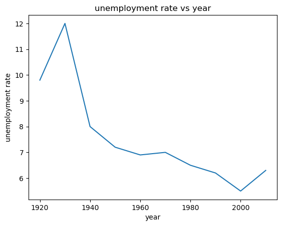

```python
year = [1920, 1930, 1940, 1950, 1960, 1970, 1980, 1990, 2000, 2010]
unemployment_rate = [9.8, 12, 8, 7.2, 6.9, 7, 6.5, 6.2, 5.5, 6.3]

plt.plot(year, unemployment_rate)
plt.title('unemployment rate vs year')
plt.xlabel('year')
plt.ylabel('unemployment rate')
plt.show()
```

# we can design the plot by using ----

# fontsize= , color= , marker='', linewidth= , linestyle='-- or ** or - or , fontweight=,

# anything else', alpha = use this for visibility, markerfacecolor = , markersize =

# plt.figure() ----here we can give figure number or set figure size

# by using (num = , figsize=(width, height))

# plt.grid(True)----we can add grid line in the plot

# plt.style.use()----to make stylish background. there are different kind of plot

# background

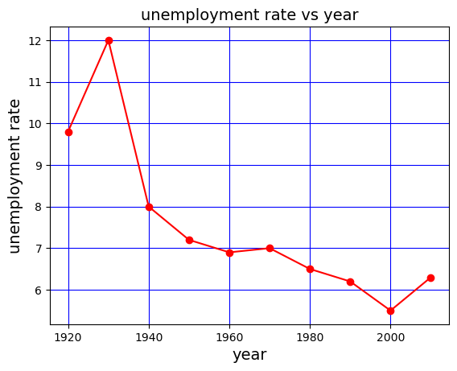

```python
plt.plot(year, unemployment_rate, color='red', marker='o')
plt.title('unemployment rate vs year', fontsize=14)
plt.xlabel('year', fontsize=14)
plt.ylabel('unemployment rate', fontsize=14)
plt.grid(True, color='blue')
plt.show()
```

# double lilne chart or multiple line chart

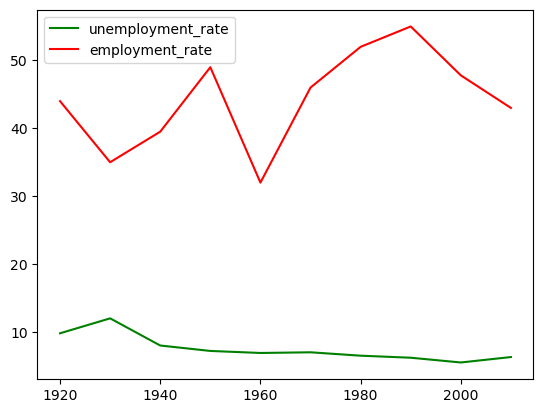

```python
year = [1920, 1930, 1940, 1950, 1960, 1970, 1980, 1990, 2000, 2010]
unemployment_rate = [9.8, 12, 8, 7.2, 6.9, 7, 6.5, 6.2, 5.5, 6.3]
employment_rate = [44, 35, 39.5, 49, 32, 46, 52, 55, 47.8, 43]

plt.plot(year, unemployment_rate, color='green', label = 'unemployment_rate')
plt.plot(year, employment_rate, color='red', label = 'employment_rate')
plt.legend()
plt.show()
```

# we can create legend two ways

# x = [data, label='']

# y = [data, label='']

# plt.legend()

# or

# plt.legend(('', ''))

# legend position = loc('best', 'upper right', 'upper left', 'lower left', 'lower right', 'right', 'center left', 'center right', 'lower center', 'upper center', 'center')

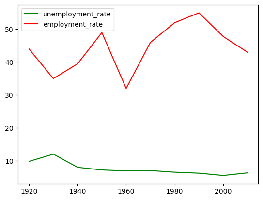

```python
year = [1920, 1930, 1940, 1950, 1960, 1970, 1980, 1990, 2000, 2010]
unemployment_rate = [9.8, 12, 8, 7.2, 6.9, 7, 6.5, 6.2, 5.5, 6.3]
employment_rate = [44, 35, 39.5, 49, 32, 46, 52, 55, 47.8, 43]

plt.plot(year, unemployment_rate, color='green')
plt.plot(year, employment_rate, color='red')
plt.legend(('unemployment_rate', 'employment_rate'))
plt.show()
```

# line chart from dataframe

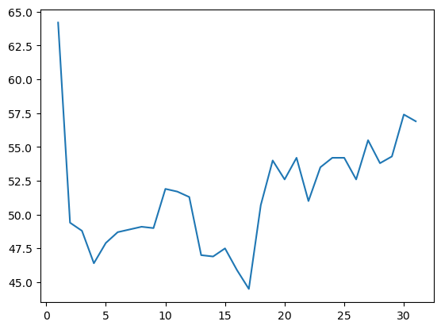

```python
plt.plot(data4['Day'], data4['AvgTemperature'])
plt.show()
```

# Bar chart

A bar plot or bar chart is a graph that represents the category of data with rectangular bars with lengths and heights that is proportional to the values which they represent. The bar plots can be plotted horizontally or vertically. A bar chart describes the comparisons between the discrete categories. One of the axis of the plot represents the specific categories being compared, while the other axis represents the measured values corresponding to those categories.

# ------------------------------------------------------------------------------------------------------

# bar chart also takes list of same number of values on both axis. value can be string or number.

# x_axis = ['value_1', 'value_2', 'value_3', ...]

# y_axis = ['value_1', 'value_2', 'value_3', ...]

# plt.bar(x_axis, y_axis)

# plt.title('title name')

# plt.xlabel('x_axis name')

# plt.ylabel('y_axis name')

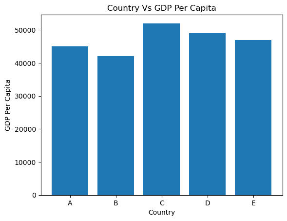

```python
country = ['A', 'B', 'C', 'D', 'E']
gdp_per_capita = [45000, 42000, 52000, 49000, 47000]

plt.bar(country, gdp_per_capita)
plt.title('Country Vs GDP Per Capita')
plt.xlabel('Country')
plt.ylabel('GDP Per Capita')
plt.show()
```

# we can use a different color for each bar

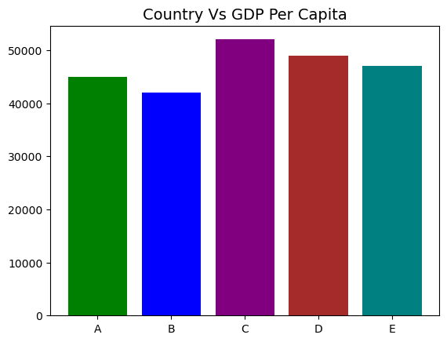

```python
colors = ['green', 'blue', 'purple', 'brown', 'teal']
plt.bar(country, gdp_per_capita, color=colors)
plt.title('Country Vs GDP Per Capita', fontsize=14)
plt.show()
```

# we can use ------

# color = '', alpha = , linestyle ='', linewidth='', width = , fontsize ='',

# fontname ='', fontstyle ='' (font style can be italic, normal)

# we can change background color of chart -------

# background = plt.axes()

# background.set_facecolor('color name')

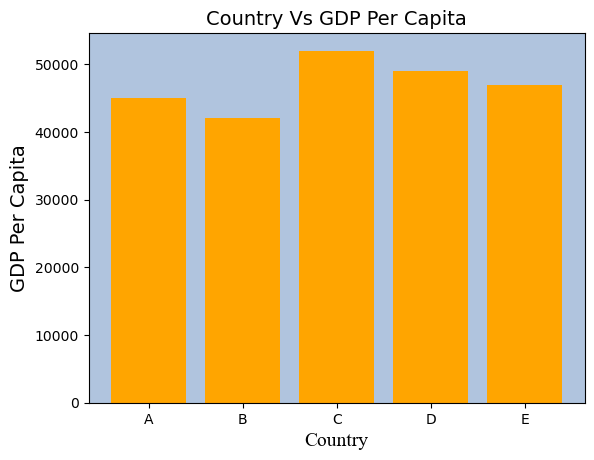

```python
country = ['A', 'B', 'C', 'D', 'E']
gdp_per_capita = [45000, 42000, 52000, 49000, 47000]

background = plt.axes()
background.set_facecolor('lightsteelblue')

plt.bar(country, gdp_per_capita, color = 'orange')
plt.title('Country Vs GDP Per Capita', fontsize=14 )
plt.xlabel('Country', fontsize=14, fontname = 'Times New Roman')
plt.ylabel('GDP Per Capita', fontsize=14)
plt.show()
```

# we can plto string data type using len() function and then converting into a list by usnig np.arange(() function.

```python
company = ['google', 'apple', 'amazon', 'microsoft']
revenue  = [27, 35, 20, 30]
```

```python
#now convert company coloumn into a list-----------
var = np.arange(len(company))
var
```

```
array([0, 1, 2, 3])
```

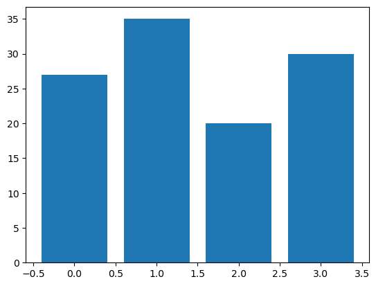

```python
plt.bar(var, revenue)
plt.show()
```

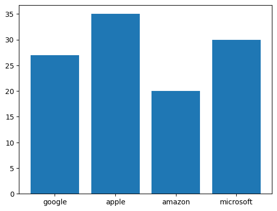

```python
#now if we want to replot the company name we have to use plt.xticks(list name, column name) fucntion---
plt.xticks(var, company)
plt.bar(var, revenue)
plt.show()
```

# stacked bar graph

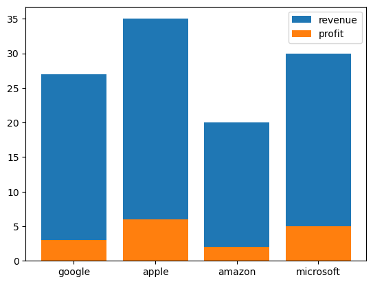

```python
company = ['google', 'apple', 'amazon', 'microsoft']
revenue  = [27, 35, 20, 30]
profit = [3, 6, 2, 5]

plt.bar(company, revenue, label = 'revenue')
plt.bar(company, profit, label = 'profit')
plt.legend()
plt.show()
```

# we can make stacked bar graph using np.arange() function

```python
company = ['google', 'apple', 'amazon', 'microsoft']
revenue  = [27, 35, 20, 30]
profit = [3, 6, 2, 5]
```

```python
xvalue = np.arange(len(company))
xvalue
```

```
array([0, 1, 2, 3])
```

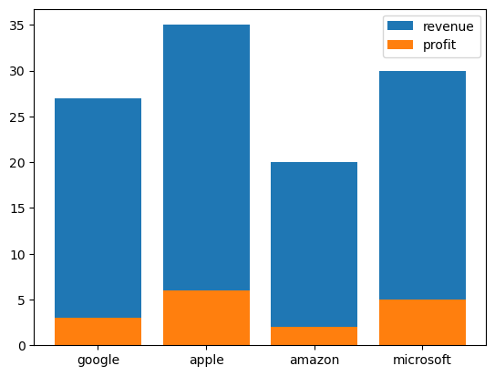

```python
plt.xticks(xvalue, company)
plt.bar(xvalue, revenue, label = 'revenue')
plt.bar(xvalue, profit, label = 'profit')
plt.legend()
plt.show()
```

# double bar chart

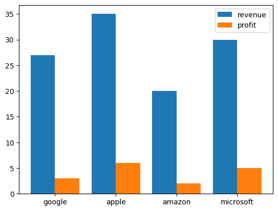

```python
plt.xticks(xvalue, company)
plt.bar(xvalue-0.2, revenue, width = 0.4, label = 'revenue')
plt.bar(xvalue + 0.2, profit, width = 0.4, label = 'profit')
plt.legend()
plt.show()
```

# multiple bar char

```python
name = ['rocky', 'harry', 'nandu', 'jule']
bangla = [74, 62, 81, 67]
english = [54, 67, 51, 39]
math = [75, 88, 55, 68]
science = [42, 55, 49, 39]
```

```python
xvalue = np.arange(len(name))
xvalue
```

```
array([0, 1, 2, 3])
```

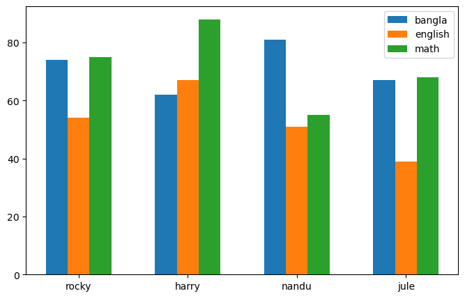

```python
plt.figure(figsize=(8, 5))

plt.xticks(xvalue, name)

plt.bar(xvalue-0.2, bangla, width=0.2, label='bangla')
plt.bar(xvalue, english, width=0.2, label='english')
plt.bar(xvalue+0.2, math, width=0.2, label='math')
plt.legend()
plt.show()
```

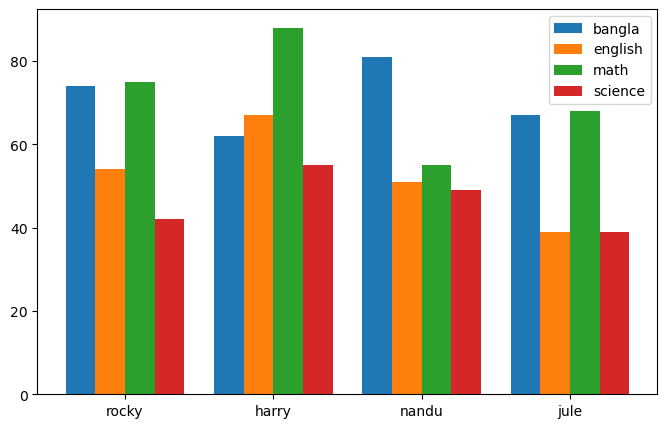

```python
plt.figure(figsize=(8, 5))

plt.xticks(xvalue, name)

plt.bar(xvalue-0.3, bangla, width=0.2, label='bangla')
plt.bar(xvalue-0.1, english, width=0.2, label='english')
plt.bar(xvalue+0.1, math, width=0.2, label='math')
plt.bar(xvalue+0.3, science, width=0.2, label='science')

plt.legend()
plt.show()
```

# horaizontal bar

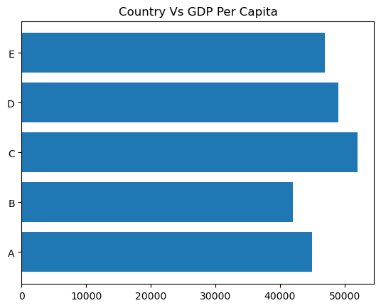

```python
country = ['A', 'B', 'C', 'D', 'E']
gdp_per_capita = [45000, 42000, 52000, 49000, 47000]

plt.barh(country, gdp_per_capita)
plt.title('Country Vs GDP Per Capita')
plt.show()
```

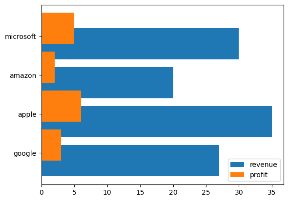

```python
plt.yticks(xvalue, company)
plt.barh(xvalue-0.2, revenue, label = 'revenue')
plt.barh(xvalue + 0.2, profit, label = 'profit')
plt.legend()
plt.show()
```

# histogram chart

histogram only take one perameter. that means we can provide one column to understand the column data. Parameters: This method accept the following parameters that are described below:

x : This parameter are the sequence of data. bins : histogram class range (10---20---30---40---50.....) range : same as bins () histtype : {‘bar’, ‘barstacked’, ‘step’, ‘stepfilled’} align : {‘left’, ‘mid’, ‘right’} rwidth : ues to detach or disjoin the bar log : used to set histogram axis to a log scale

# ---------------------------------------------------------------------------------------------------

# basic structure

# x = [value1, value2, value3,....]

# plt.hist(x, bins=number or [range], )

# plt.show()

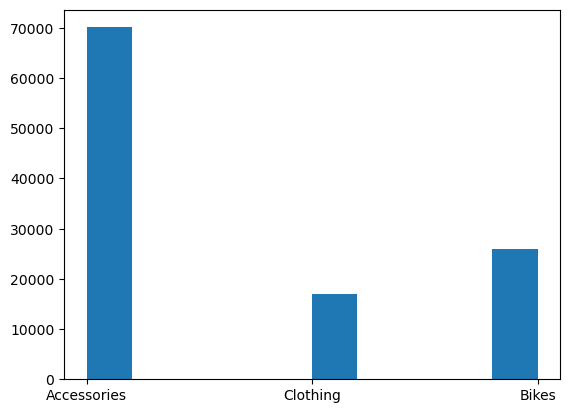

```python
plt.hist(data1['Product_Category'])
plt.show()
```

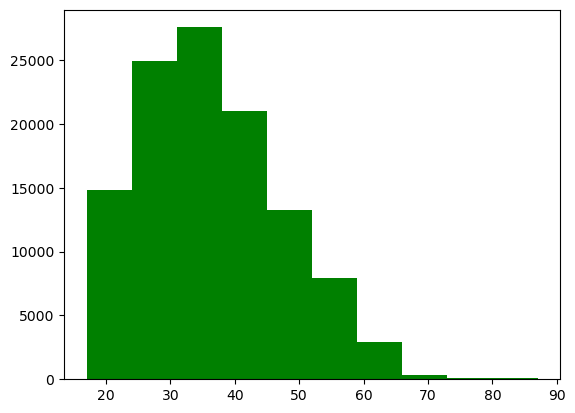

```python
plt.hist(data1['Customer_Age'], color='green')
plt.show()
```

# horizontal histogram

# histogram can be horizontal, vartical

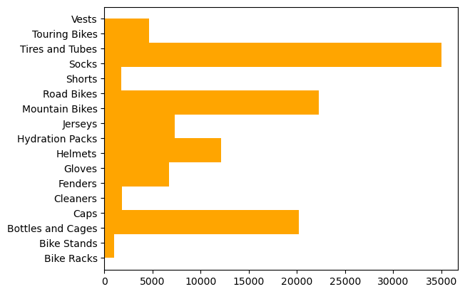

```python
plt.hist(data1['Sub_Category'], color='orange', orientation='horizontal')
plt.show()
```

# scatter plot

# ------------------------------------------------------------------------------------------------

Scatter plots’ primary uses are to observe and show relationships between two numeric variables. The dots in a scatter plot not only report the values of individual data points, but also patterns when the data are taken as a whole. Identification of correlational relationships are common with scatter plots. In these cases, we want to know, if we were given a particular horizontal value, what a good prediction would be for the vertical value. You will often see the variable on the horizontal axis denoted an independent variable, and the variable on the vertical axis the dependent variable. Relationships between variables can be described in many ways: positive or negative, strong or weak, linear or nonlinear.

# basic structure of scatter plot

we have to use two perameters x and y. both must have same number values. means both columns must have same number of data. and values should be use as a list.

# x_axis = ['value_1', 'value_2', 'value_3', ...]

# y_axis = ['value_1', 'value_2', 'value_3', ...]

# plt.scatter(x_axis, y_axis)

# plt.title('title name')

# plt.xlabel('x_axis name')

# plt.ylabel('y_axis name')

# plt.show

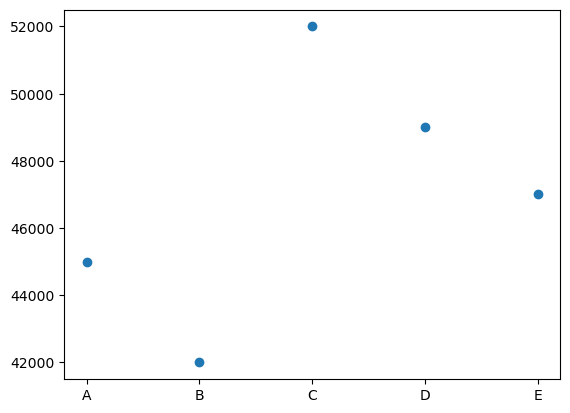

```python
country = ['A', 'B', 'C', 'D', 'E']
gdp_per_capita = [45000, 42000, 52000, 49000, 47000]


plt.scatter(country, gdp_per_capita)
plt.show()
```

# x_axis_data- An array containing x-axis data

# y_axis_data- An array containing y-axis data

# s- marker size (can be scalar or array of size equal to size of x or y)

# c- color of sequence of colors for markers

# marker- marker style

# cmap- cmap name

# linewidths- width of marker border

# edgecolor- marker border color

# alpha- blending value, between 0 (transparent) and 1 (opaque)

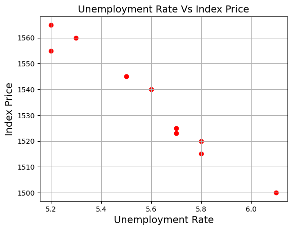

```python
data = {'unemployment_rate': [6.1, 5.8, 5.7, 5.7, 5.8, 5.6, 5.5, 5.3, 5.2, 5.2],
        'index_price': [1500, 1520, 1525, 1523, 1515, 1540, 1545, 1560, 1555, 1565]
        }

df = pd.DataFrame(data)

plt.scatter(df['unemployment_rate'], df['index_price'], color='red')
plt.title('Unemployment Rate Vs Index Price', fontsize=14)
plt.xlabel('Unemployment Rate', fontsize=14)
plt.ylabel('Index Price', fontsize=14)
plt.grid(True)
plt.show()
```

# pie chart

# ---------------------------------------------------------------------------------------------------------

pie chart takes one value. data type needs to be float, integer. string data or negative values wont take. A Pie Chart is a circular statistical plot that can display only one series of data. The area of the chart is the total percentage of the given data. The area of slices of the pie represents the percentage of the parts of the data. The slices of pie are called wedges. The area of the wedge is determined by the length of the arc of the wedge. The area of a wedge represents the relative percentage of that part with respect to whole data. Pie charts are commonly used in business presentations like sales, operations, survey results, resources, etc as they provide a quick summary.

# basic structure of a pie chart

data labels color shadow

# data = [value1, value2, value3, ...]

# labels = 'label1', 'label2', 'label3', ...

# plt.pie(data, labels = labels)

# plt.show()

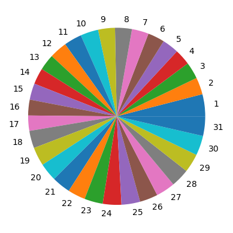

```python
plt.pie(data4['AvgTemperature'], labels = data4['Day'])
plt.show()
```

# design a pie chart

explode= if we want to explode any part of the pie chart, labels= name of each part, radius= the size of the pie chart colors= color of each part (for this we have to make a list of color first than input here) autopct='% 0.0f%%'---- if we want to show the parcentage of the each part startangle=, wedgeprops=, textprops=, , shadow=(True/False)

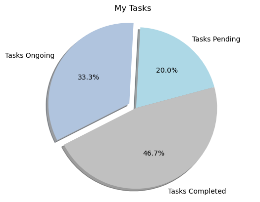

```python
data = [300, 500, 700]
labels = 'Tasks Pending', 'Tasks Ongoing', 'Tasks Completed'
colors = ['lightblue', 'lightsteelblue', 'silver']
explode = (0, 0.1, 0)
plt.pie(data, labels=labels, autopct='%1.1f%%', startangle=15, shadow=True, colors=colors, explode=explode)
plt.title('My Tasks')
plt.axis('equal')
plt.show()
```

# bar chart with line plot

# --------------------------------------------------------------------------------------------------

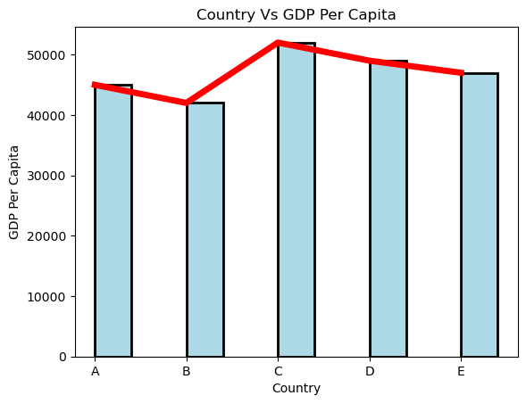

```python
country = ['A', 'B', 'C', 'D', 'E']
gdp_per_capita = [45000, 42000, 52000, 49000, 47000]

plt.bar(country, gdp_per_capita, color='lightblue', width=0.4, align='edge', edgecolor='black', linewidth=2)
plt.plot(country, gdp_per_capita, color='red', linewidth=5)

plt.title('Country Vs GDP Per Capita')
plt.xlabel('Country')
plt.ylabel('GDP Per Capita')
plt.show()
```

# scatter + line chart

# ------------------------------------------------------------------------------------------------

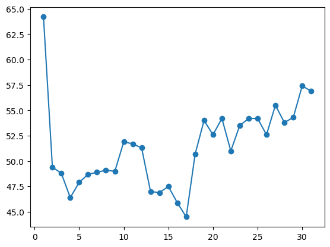

```python
plt.plot(data4['Day'], data4['AvgTemperature'])
plt.scatter(data4['Day'], data4['AvgTemperature'])
plt.show()
```

# scatter plot with best fit line using matplotlib

# ----------------------------------------------------------------------------------------------------

# first we have to make the best fit line ploting...for this reason fi=rt we have to calculate

# best fit line by np.polyfit (x value, y value, 1) and put this into a variable.

# then we have to convert the variable into polynomial function. then put this into a new variable again.

# the the new variable canbe apply to plot like this way plt.plot(x value, new_variable(x value))

The numpy.poly1d() function helps to define a polynomial function. It makes it easy to apply “natural operations” on polynomials.

Syntax: numpy.poly1d(arr, root, var) Parameters : arr : [array_like] The polynomial coefficients are given in decreasing order of powers. If the second parameter (root) is set to True then array values are the roots of the polynomial equation. root : [bool, optional] True means polynomial roots. Default is False. var : variable like x, y, z that we need in polynomial [default is x]. Arguments : c : Polynomial coefficient. coef : Polynomial coefficient. coefficients : Polynomial coefficient. order : Order or degree of polynomial. o : Order or degree of polynomial. r : Polynomial root. roots : Polynomial root. Return: Polynomial and the operation applied

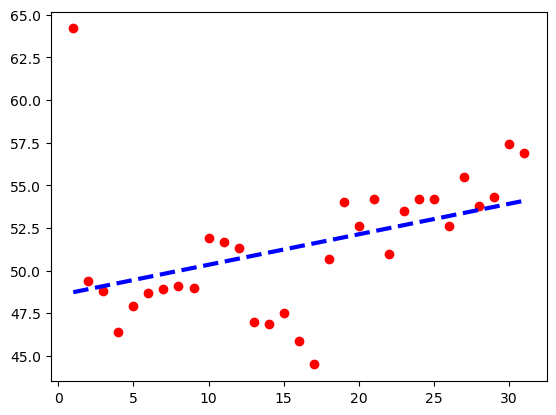

```python
#calculating best fit line--------------

calcu_making_trendline = np.polyfit (data4['Day'], data4['AvgTemperature'], 1)
bestfitline = np.poly1d(calcu_making_trendline)


plt.scatter(data4['Day'], data4['AvgTemperature'], color='red')
plt.plot(data4['Day'], bestfitline(data4['Day']), color="blue", linewidth=3, linestyle="--")
plt.show()
```